# M2.891_20241_PEC1-Solucion

[figure not shown]

M2.891 · Aprendizaje automático · PEC1

2024-1 · Máster universitario en Ciencia de datos (Data science)

Estudios de Informática, Multimedia y Telecomunicación

**PEC 1: Preparación de datos**

El objetivo principal de esta primera PEC es que os familiaricéis con el entorno de trabajo que utilizaréis en el resto de prácticas de la asignatura. Dicho entorno estará formado por un conjunto de dependencias relativas a ciertos módulos de Python que serán necesarios para poder ejecutar de forma correcta vuestra PEC. Estas dependencias las gestionaremos gracias a la ayuda de Anaconda. Otra de las herramientas fundamentales del que será vuestro nuevo entorno de trabajo será Jupyter, que os permitirá trabajar con Notebooks (ficheros *.ipynb) como el presente enunciado.

Otro de los aspectos más importantes que cubriremos en esta primera PEC, tal y como adelanta su título, es el de la preparación de los datos. En esta PEC aprenderemos a cargar un conjunto de datos o *dataset* y nos ayudaremos de herramientas de visualización para comprender mejor cómo se distribuye el dato de cara a entender cómo podemos sacarle partido. Además, nos habituaremos a trabajar con conjuntos de entrenamiento y test para confirmar si las conclusiones que sacamos sobre una parte de las muestras se pueden generalizar y extrapolar al resto.

En resumen, en esta práctica veremos cómo aplicar diferentes técnicas para la carga y preparación de datos siguiendo los pasos listados a continuación:

1. Carga de un conjunto de datos (1 punto)
2. Análisis de los datos (2.5 puntos)

2.1. Análisis estadístico básico  
2.2. Análisis exploratorio de los datos 4. Preprocesado de los datos (1.5 puntos) 5. Reducción de la dimensionalidad (2.5 puntos) 6. Conjuntos desbalanceados de datos (2.5 puntos)  
6.1. Oversampling

**Importante:** cada uno de los ejercicios puede suponer varios minutos de ejecución, por lo que la entrega debe hacerse en formato notebook y en formato html, donde se vea el código, los resultados y comentarios de cada ejercicio. Se puede exportar el notebook a html desde el menú File $\to$ Download as $\to$ HTML.

**Importante:** existe un tipo de celda especial para albergar texto. Este tipo de celda os será muy útil para responder a las diferentes preguntas teóricas planteadas a lo largo de cada PEC. Para cambiar el tipo de celda a este tipo, elegid en el menú: Cell $\to$ Cell Type $\to$ Markdown.

**Importante:** la solución planteada no debe utilizar métodos, funciones o parámetros declarados "deprecated" en futuras versiones.

**Importante:** no olvidéis poner vuestro nombre y apellidos en la siguiente celda.

**Nombre y apellidos:**

Para la realización de la práctica necesitaremos importar los siguientes módulos:

```python
import numpy as np
import pandas as pd
from sklearn import preprocessing
from sklearn.manifold import TSNE
from sklearn.decomposition import PCA
from sklearn.model_selection import train_test_split
from imblearn.over_sampling import RandomOverSampler, SMOTE, ADASYN

import matplotlib
import matplotlib.pyplot as plt

pd.set_option('display.max_columns', None)
seed = 100

%matplotlib inline
```

# Carga del conjunto de datos (1 punto)

A lo largo de toda la PEC trabajaremos con el conjunto de datos llamado *Bank Marketing*, que es uno de los *datasets* disponibles en el [Repositorio de Apdendizaje automático de la Universidad de California en Irvine](https://archive.ics.uci.edu/).

En el enlace [https://archive.ics.uci.edu/dataset/222/bank+marketing] tenéis disponible tanto el mencionado conjunto de datos *Bank Marketing* como toda la información relevante necesaria para comprender mejor con qué tipo de dato vamos a trabajar. En resumen, los datos de este *dataset* están relacionados con campañas de marketing directo (llamadas telefónicas) de una institución bancaria portuguesa. El objetivo que se busca en este conjunto de datos es el de predecir si el cliente contratará un depósito a plazo o no (variable *y*).

En primer lugar, deberéis cargar en el Notebook el conjunto de datos con el que trabajaremos durante el resto de la PEC. Para ello, podéis descargarlo manualmente del enlace referido previamente, aunque os aconsejamos que instaléis y utilicéis el módulo *ucimlrepo* tal y como se explica en la propia página del *dataset*.

**Ejercicio:** cargad el conjunto de datos "Bank Marketing" y mostrad:

- El número y nombre de los atributos descriptivos (variables que podrían ser usadas para predecir la variable objetivo "y").
- El número de filas (muestras) del conjunto de datos.
- Verificad si hay o no "missing values" y en qué columnas.

Sugerencia: si usáis ucimlrepo, explorad los atributos *metadata* y *variables* del objeto obtenido.

Sugerencia: separad el conjunto de datos original en las variables "X" (atributos descriptivos) e "y" (variable objetivo), aunque quizá pueda serte de utilidad en algún punto tenerlos también en un único DataFrame combinados.

**Solución:**

```python
!pip install ucimlrepo==0.0.7
```

```python
from ucimlrepo import fetch_ucirepo

# fetch dataset
bank_marketing = fetch_ucirepo(id=222)

# data (as pandas dataframes)
X = bank_marketing.data.features
y = bank_marketing.data.targets
```

```python
# metadata
print(bank_marketing.metadata)
```

```
{'uci_id': 222, 'name': 'Bank Marketing', 'repository_url': 'https://archive.ics.uci.edu/dataset/222/bank+marketing', 'data_url': 'https://archive.ics.uci.edu/static/public/222/data.csv', 'abstract': 'The data is related with direct marketing campaigns (phone calls) of a Portuguese banking instituti…
```

```python
# variable information
print(bank_marketing.variables)
```

```
           name     role         type      demographic  \
0           age  Feature      Integer              Age
1           job  Feature  Categorical       Occupation
2       marital  Feature  Categorical   Marital Status
3     education  Feature  Categorical  Education Level
4       default  Feature       Binary             None
5       balance  Feature      Integer             None
6       housing  Feature       Binary             None
7          loan  Feature       Binary             None
8       contact  Feature  Categorical             None
9   day_of_week  Feature         Date             None
10        month  Feature         Date             None
11     duration  Feature      Integer             None
12     campaign  Feature      Integer             None
13        pdays  Feature      Integer             None
```

[output cut: 22 more lines]

```python
print("# rows X:", np.shape(X)[0])
print("# rows y:", np.shape(y)[0])
print("# feature columns:", np.shape(X)[1])
print("Feature columns:", ", ".join(X.columns.values))
```

```
# rows X: 45211
# rows y: 45211
# feature columns: 16
Feature columns: age, job, marital, education, default, balance, housing, loan, contact, day_of_week, month, duration, campaign, pdays, previous, poutcome
```

```python
bank_marketing_df = pd.concat([X, y], axis='columns')
bank_marketing_df.head(2)
```

|  | age | job | marital | education | default | balance | housing | loan | contact | day_of_week | month | duration | campaign | pdays | previous | poutcome | y |
| --- | --- | --- | --- | --- | --- | --- | --- | --- | --- | --- | --- | --- | --- | --- | --- | --- | --- |
| 0 | 58 | management | married | tertiary | no | 2143 | yes | no | NaN | 5 | may | 261 | 1 | -1 | 0 | NaN | no |
| 1 | 44 | technician | single | secondary | no | 29 | yes | no | NaN | 5 | may | 151 | 1 | -1 | 0 | NaN | no |

```python
bank_marketing_df.isnull().sum()
```

```
age                0
job              288
marital            0
education       1857
default            0
balance            0
housing            0
loan               0
contact        13020
day_of_week        0
month              0
duration           0
campaign           0
pdays              0
previous           0
poutcome       36959
y                  0
dtype: int64
```

**Pregunta:** ¿el conjunto de datos propuesto es un problema de aprendizaje automático supervisado o no?, en el caso de serlo, ¿de qué tipo de aprendizaje supervisado estaríamos hablando?

**Solución:** se trata de un problema de aprendizaje automático supervisado de clasificación.

# Análisis de los datos (2.5 puntos)

En este apartado visualizaremos cada una de las columnas o *features* del dato para comprender mejor qué distribución tiene.

## Análisis estadístico básico

**Ejercicio:** realizad un análisis estadístico básico:

- Variables categóricas:
- Calculad la frecuencia.
- Haced un gráfico de barras para cada variable.
- Variables numéricas:
- Calculad estadísticos descriptivos básicos: media, mediana, desviación estandard, ...
- Haced un histograma para cada variable.

Sugerencia: podéis usar la librería "pandas" y sus funciones "describe" y "value_counts", así como las funciones "bar", "hist" y "hist2d" de *matplotlib*.

**Solución:**

```
job
admin.           5171
blue-collar      9732
entrepreneur     1487
housemaid        1240
management       9458
retired          2264
self-employed    1579
services         4154
student           938
technician       7597
unemployed       1303
Name: count, dtype: int64
marital
divorced     5207
married     27214
single      12790
Name: count, dtype: int64
education
primary       6851
secondary    23202
tertiary     13301
Name: count, dtype: int64
default
no     44396
yes      815
Name: count, dtype: int64
housing
no     20081
yes    25130
Name: count, dtype: int64
loan
no     37967
yes     7244
Name: count, dtype: int64
contact
cellular     29285
telephone     2906
Name: count, dtype: int64
day_of_week
```

[output cut: 40 more lines]

```
mar      477
may    13766
nov     3970
oct      738
sep      579
Name: count, dtype: int64
poutcome
failure    4901
other      1840
success    1511
Name: count, dtype: int64
y
no     39922
yes     5289
Name: count, dtype: int64
```

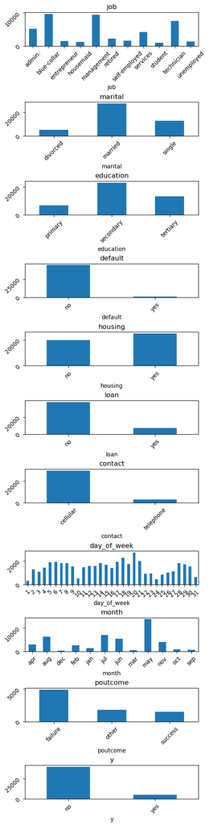

```python
categorical_columns = ["job", "marital", "education", "default", "housing", "loan", "contact", "day_of_week", "month", "poutcome", "y"]

fig, ax = plt.subplots(len(categorical_columns), figsize = (5, 20), constrained_layout=True)
for i, column in enumerate(categorical_columns):
    freq = bank_marketing_df.sort_values(column)[column].value_counts(sort=False)
    print(freq)
    freq.plot.bar(ax=ax[i])
    ax[i].tick_params(labelrotation=45)  # to avoid labels overlapping in X ticks due to long names
    ax[i].set_title(column)

plt.show()
```

```python
X.describe()
```

|  | age | balance | day_of_week | duration | campaign | pdays | previous |
| --- | --- | --- | --- | --- | --- | --- | --- |
| count | 45211.000000 | 45211.000000 | 45211.000000 | 45211.000000 | 45211.000000 | 45211.000000 | 45211.000000 |
| mean | 40.936210 | 1362.272058 | 15.806419 | 258.163080 | 2.763841 | 40.197828 | 0.580323 |
| std | 10.618762 | 3044.765829 | 8.322476 | 257.527812 | 3.098021 | 100.128746 | 2.303441 |
| min | 18.000000 | -8019.000000 | 1.000000 | 0.000000 | 1.000000 | -1.000000 | 0.000000 |
| 25% | 33.000000 | 72.000000 | 8.000000 | 103.000000 | 1.000000 | -1.000000 | 0.000000 |
| 50% | 39.000000 | 448.000000 | 16.000000 | 180.000000 | 2.000000 | -1.000000 | 0.000000 |
| 75% | 48.000000 | 1428.000000 | 21.000000 | 319.000000 | 3.000000 | -1.000000 | 0.000000 |
| max | 95.000000 | 102127.000000 | 31.000000 | 4918.000000 | 63.000000 | 871.000000 | 275.000000 |

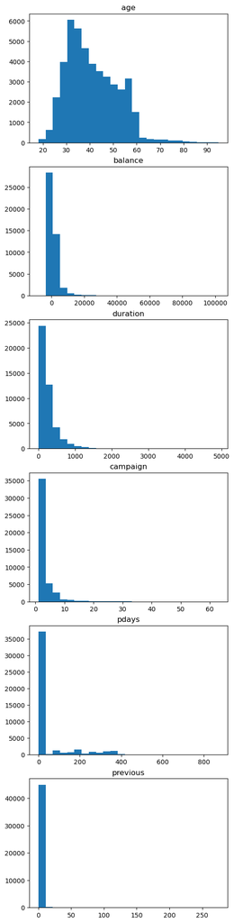

```python
numeric_columns = [column for column in bank_marketing_df.columns.values if column not in categorical_columns]

fig, ax = plt.subplots(len(numeric_columns), figsize = (5, 20), constrained_layout=True)
for i, column in enumerate(numeric_columns):
    ax[i].hist(bank_marketing_df[column], bins=25)
    ax[i].set_title(column)

plt.show()
```

**Análisis:** comentad los resultados.

**Solución:**  
Existen variables descriptivas con distintas distribuciones, unas más uniformes, otras muy desbalanceadas y, en algún caso, como en el de la edad, similares a una distribución normal. El caso de "pdays" y "previous" es llamativo ya que la gran mayoría de sus valores tienden a cero, además, probablemente debido a *outliers* o valores extremos tengan esa forma denominada como larga cola o *long tail*. Por otro lado, podemos ver que las escalas de las diferentes variables numéricas son muy diferentes entre sí.

## Análisis exploratorio de los datos

En este subapartado exploraremos gráficamente la relación de los atributos descriptivos con la variable objetivo y analizaremos las diferentes correlaciones.

**Ejercicio:** usando una librería gráfica, como por ejemplo *matplotlib*, para cada una de las variables categóricas, superponed en un mismo gráfico el diagrama de barras para cada posible valor de la variable objetivo, diferenciando con distinto color según el valor de "y", es decir, cuando sea "no" o cuando sea "yes". Añadid una leyenda para saber a qué clase corresponde cada histograma.

La finalidad es observar cómo se distribuye cada uno de los atributos en función de la clase que tengan, para poder identificar de manera visual y rápida si algunos atributos nos permiten predecir mejor que otros el valor de la variable objetivo.

Sugerencia: podéis usar el parámetro "alpha" en los gráficos para que se aprecien los dos histogramas.

**Solución:**

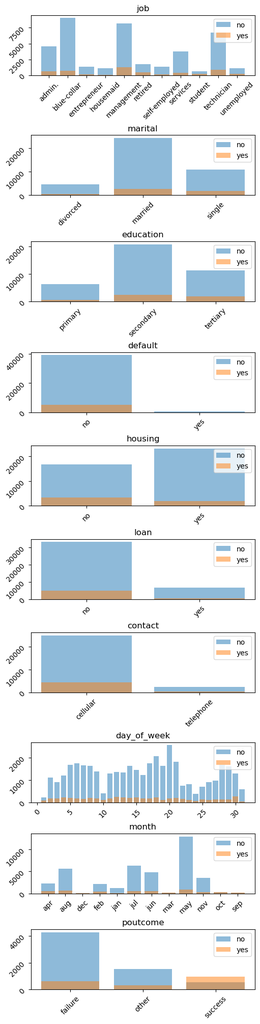

```python
fig, ax = plt.subplots(len(categorical_columns)-1, figsize = (5, 20), constrained_layout=True)

for i, column in enumerate(categorical_columns):
    if column != "y":
        for y_value in bank_marketing_df["y"].unique():
            freq = bank_marketing_df.sort_values(column).loc[bank_marketing_df["y"]==y_value, column].value_counts(sort=False)
            ax[i].bar(freq.keys(), freq.values, alpha=0.5, label=y_value)
            ax[i].tick_params(labelrotation=45)
            ax[i].set_title(column)
            ax[i].legend(loc='upper right')

plt.show()
```

**Ejercicio:** de la misma forma que en el ejercicio anterior, superponed los histogramas para los distintos valores de "y" para cada variable numérica.

**Solución:**

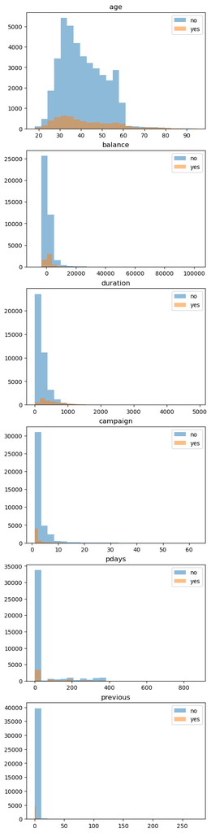

```python
fig, ax = plt.subplots(len(numeric_columns), figsize = (5, 20), constrained_layout=True)

for i, column in enumerate(numeric_columns):
    for y_value in bank_marketing_df["y"].unique():
        ax[i].hist(bank_marketing_df.loc[bank_marketing_df["y"]==y_value, column], bins=25, label=y_value, alpha=0.5)
        ax[i].set_title(column)
        ax[i].legend(loc='upper right')

plt.show()
```

**Análisis:**  
Mirando los gráficos de barras y los histogramas, ¿qué atributos parecen tener más peso a la hora de predecir si se contratara un depósito a plazo o no? ¿Crees que con estos atributos será suficiente para poder determinar si se contratará o no el depósito?

**Solución:**  
Atendiendo a que el conjunto de datos está muy desbalanceado hacia la clase "no" de "y", es llamativo que haya tantos "yes" como "no" para personas de más de 60 años, por ejemplo, o el día 30 del mes, o en ciertos meses como septiembre u octubre. Sin embargo, a priori, utilizando por separado cada uno de los atributos descriptivos no parece que podamos determinar claramente cuándo se va a contratar el depósito. No obstante, habría que ver si de la combinación de todos los atributos a la vez surge la posibilidad de separar las muestras de una clase de la otra.

**Ejercicio:** calculad y mostrad la correlación entre las variables numéricas.

**Solución:**

```python
corr_all = bank_marketing_df[numeric_columns].corr()
corr_all.style.format(precision=2).background_gradient(cmap='coolwarm')
```

|  | age | balance | duration | campaign | pdays | previous |
| --- | --- | --- | --- | --- | --- | --- |
| age | 1.00 | 0.10 | -0.00 | 0.00 | -0.02 | 0.00 |
| balance | 0.10 | 1.00 | 0.02 | -0.01 | 0.00 | 0.02 |
| duration | -0.00 | 0.02 | 1.00 | -0.08 | -0.00 | 0.00 |
| campaign | 0.00 | -0.01 | -0.08 | 1.00 | -0.09 | -0.03 |
| pdays | -0.02 | 0.00 | -0.00 | -0.09 | 1.00 | 0.45 |
| previous | 0.00 | 0.02 | 0.00 | -0.03 | 0.45 | 1.00 |

**Análisis:** comenta los resultados.

**Solución:** por lo general, las variables son muy independientes. Sin embargo, es muy llamativo el caso de "pdays" y "previous", aunque echando la vista atrás y viendo sus histogramas, donde la gran mayoría de sus valores tienden a cero, tiene sentido este alto valor de correlación.